# INTRODUCTION

In recent years, we have seen that machine learning has grown as an emerging technology in the world. It has its implementation almost everywhere such as Image Recognition, Speech Recognition, Traffic Recognition, Self-driving cars, and many more. ,. One area where machine learning can be applied is in predicting whether a patient is suffering from heart diseases or not. This information help patient to better understand risk in heart diseases. This prediction can reduce the risk of heart attack.

Our goal is to build a predictive model that accurately identifies if the patient suffering from heart attack or not based on the factor associated such as their age, sex, cholesterol etc. By leveraging machine learning techniques, we can improve the accuracy and efficiency of these processes, and ultimately provide better service to our patient.

# PROBLEM STATEMENT

In order to solve the problem, we are developing a machine learning model that will allow users to anticipate whether or not they will experience a heart attack.

First, we need to import the libraries we'll need for our prediction.

```python
import numpy as np
import pandas as pd
import matplotlib.pyplot as plt
import seaborn as sns

import warnings
warnings.filterwarnings('ignore')
```

Importing the dataset that can be used to train an algorithm

Heart Disease & Stroke Prevention Data

```python
df = pd.read_csv(r'C:\Users\Admin\Downloads\heart (1).csv')
df
```

|  | age | sex | cp | trtbps | chol | fbs | restecg | thalachh | exng | oldpeak | slp | caa | thall | output |
| --- | --- | --- | --- | --- | --- | --- | --- | --- | --- | --- | --- | --- | --- | --- |
| 0 | 63 | 1 | 3 | 145 | 233 | 1 | 0 | 150 | 0 | 2.3 | 0 | 0 | 1 | 1 |
| 1 | 37 | 1 | 2 | 130 | 250 | 0 | 1 | 187 | 0 | 3.5 | 0 | 0 | 2 | 1 |
| 2 | 41 | 0 | 1 | 130 | 204 | 0 | 0 | 172 | 0 | 1.4 | 2 | 0 | 2 | 1 |
| 3 | 56 | 1 | 1 | 120 | 236 | 0 | 1 | 178 | 0 | 0.8 | 2 | 0 | 2 | 1 |
| 4 | 57 | 0 | 0 | 120 | 354 | 0 | 1 | 163 | 1 | 0.6 | 2 | 0 | 2 | 1 |
| ... | ... | ... | ... | ... | ... | ... | ... | ... | ... | ... | ... | ... | ... | ... |
| 298 | 57 | 0 | 0 | 140 | 241 | 0 | 1 | 123 | 1 | 0.2 | 1 | 0 | 3 | 0 |
| 299 | 45 | 1 | 3 | 110 | 264 | 0 | 1 | 132 | 0 | 1.2 | 1 | 0 | 3 | 0 |
| 300 | 68 | 1 | 0 | 144 | 193 | 1 | 1 | 141 | 0 | 3.4 | 1 | 2 | 3 | 0 |
| 301 | 57 | 1 | 0 | 130 | 131 | 0 | 1 | 115 | 1 | 1.2 | 1 | 1 | 3 | 0 |
| 302 | 57 | 0 | 1 | 130 | 236 | 0 | 0 | 174 | 0 | 0.0 | 1 | 1 | 2 | 0 |

303 rows × 14 columns

Describe the data

The information about the patient is described in 14 columns and multiple rows in the data and objects define its dtypes.

```python
df.columns
```

```
Index(['age', 'sex', 'cp', 'trtbps', 'chol', 'fbs', 'restecg', 'thalachh',
       'exng', 'oldpeak', 'slp', 'caa', 'thall', 'output'],
      dtype='object')
```

Checking for null values in the data is the next move.

```python
df.isnull().sum()
```

```
age         0
sex         0
cp          0
trtbps      0
chol        0
fbs         0
restecg     0
thalachh    0
exng        0
oldpeak     0
slp         0
caa         0
thall       0
output      0
dtype: int64
```

Check the data's information

```python
df.info()
```

```
<class 'pandas.core.frame.DataFrame'>
RangeIndex: 303 entries, 0 to 302
Data columns (total 14 columns):
 #   Column    Non-Null Count  Dtype
---  ------    --------------  -----
 0   age       303 non-null    int64
 1   sex       303 non-null    int64
 2   cp        303 non-null    int64
 3   trtbps    303 non-null    int64
 4   chol      303 non-null    int64
 5   fbs       303 non-null    int64
 6   restecg   303 non-null    int64
 7   thalachh  303 non-null    int64
 8   exng      303 non-null    int64
 9   oldpeak   303 non-null    float64
 10  slp       303 non-null    int64
 11  caa       303 non-null    int64
 12  thall     303 non-null    int64
 13  output    303 non-null    int64
dtypes: float64(1), int64(13)
memory usage: 33.3 KB
```

To display some fundamental statistical information like min, max, mean, Std, etc.

```python
df.describe()
```

|  | age | sex | cp | trtbps | chol | fbs | restecg | thalachh | exng | oldpeak | slp | caa | thall | output |
| --- | --- | --- | --- | --- | --- | --- | --- | --- | --- | --- | --- | --- | --- | --- |
| count | 303.000000 | 303.000000 | 303.000000 | 303.000000 | 303.000000 | 303.000000 | 303.000000 | 303.000000 | 303.000000 | 303.000000 | 303.000000 | 303.000000 | 303.000000 | 303.000000 |
| mean | 54.366337 | 0.683168 | 0.966997 | 131.623762 | 246.264026 | 0.148515 | 0.528053 | 149.646865 | 0.326733 | 1.039604 | 1.399340 | 0.729373 | 2.313531 | 0.544554 |
| std | 9.082101 | 0.466011 | 1.032052 | 17.538143 | 51.830751 | 0.356198 | 0.525860 | 22.905161 | 0.469794 | 1.161075 | 0.616226 | 1.022606 | 0.612277 | 0.498835 |
| min | 29.000000 | 0.000000 | 0.000000 | 94.000000 | 126.000000 | 0.000000 | 0.000000 | 71.000000 | 0.000000 | 0.000000 | 0.000000 | 0.000000 | 0.000000 | 0.000000 |
| 25% | 47.500000 | 0.000000 | 0.000000 | 120.000000 | 211.000000 | 0.000000 | 0.000000 | 133.500000 | 0.000000 | 0.000000 | 1.000000 | 0.000000 | 2.000000 | 0.000000 |
| 50% | 55.000000 | 1.000000 | 1.000000 | 130.000000 | 240.000000 | 0.000000 | 1.000000 | 153.000000 | 0.000000 | 0.800000 | 1.000000 | 0.000000 | 2.000000 | 1.000000 |
| 75% | 61.000000 | 1.000000 | 2.000000 | 140.000000 | 274.500000 | 0.000000 | 1.000000 | 166.000000 | 1.000000 | 1.600000 | 2.000000 | 1.000000 | 3.000000 | 1.000000 |
| max | 77.000000 | 1.000000 | 3.000000 | 200.000000 | 564.000000 | 1.000000 | 2.000000 | 202.000000 | 1.000000 | 6.200000 | 2.000000 | 4.000000 | 3.000000 | 1.000000 |

NOTE:- There are no unnecessary columns that we need to eliminate, thus the training process will continue.

The data will now be used to create some insights using various graphical representations.

countplot

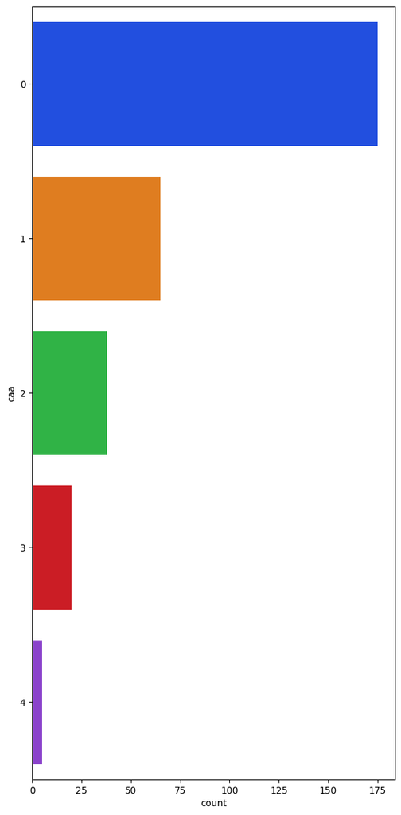

```python
plt.figure(figsize = (7,15))
sns.countplot(y = df['caa'],data=df,dodge=False,palette='bright')
plt.show()
```

Regression Line

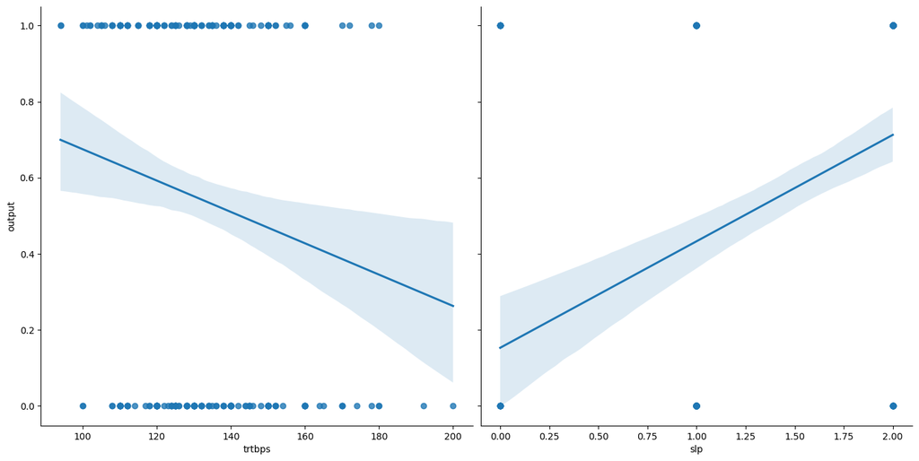

```python
plt.figure(figsize = (6,7))
sns.pairplot(x_vars=['trtbps','slp'],data=df,y_vars='output',kind='reg',size = 7)
plt.show()
```

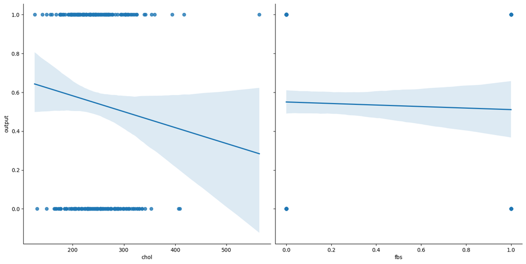

```python
plt.figure(figsize = (6,7))
sns.pairplot(x_vars=['chol','fbs'],data=df,y_vars='output',kind='reg',size = 7)
plt.show()
```

Pie Chart

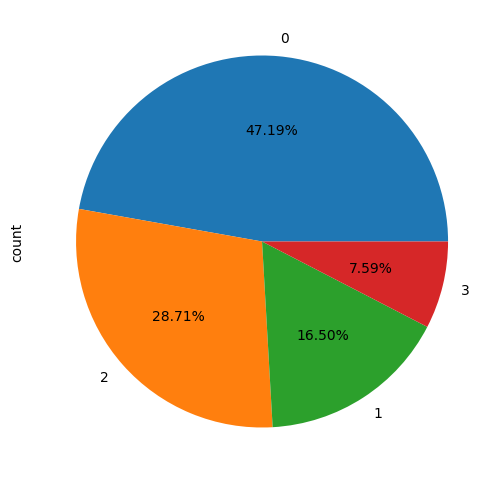

```python
plt.figure(figsize = (6,7))
df['cp'].value_counts().plot(kind = 'pie',autopct = '%1.2f%%')
plt.show()
```

Correlation

```python
df.corr()
```

|  | age | sex | cp | trtbps | chol | fbs | restecg | thalachh | exng | oldpeak | slp | caa | thall | output |
| --- | --- | --- | --- | --- | --- | --- | --- | --- | --- | --- | --- | --- | --- | --- |
| age | 1.000000 | -0.098447 | -0.068653 | 0.279351 | 0.213678 | 0.121308 | -0.116211 | -0.398522 | 0.096801 | 0.210013 | -0.168814 | 0.276326 | 0.068001 | -0.225439 |
| sex | -0.098447 | 1.000000 | -0.049353 | -0.056769 | -0.197912 | 0.045032 | -0.058196 | -0.044020 | 0.141664 | 0.096093 | -0.030711 | 0.118261 | 0.210041 | -0.280937 |
| cp | -0.068653 | -0.049353 | 1.000000 | 0.047608 | -0.076904 | 0.094444 | 0.044421 | 0.295762 | -0.394280 | -0.149230 | 0.119717 | -0.181053 | -0.161736 | 0.433798 |
| trtbps | 0.279351 | -0.056769 | 0.047608 | 1.000000 | 0.123174 | 0.177531 | -0.114103 | -0.046698 | 0.067616 | 0.193216 | -0.121475 | 0.101389 | 0.062210 | -0.144931 |
| chol | 0.213678 | -0.197912 | -0.076904 | 0.123174 | 1.000000 | 0.013294 | -0.151040 | -0.009940 | 0.067023 | 0.053952 | -0.004038 | 0.070511 | 0.098803 | -0.085239 |
| fbs | 0.121308 | 0.045032 | 0.094444 | 0.177531 | 0.013294 | 1.000000 | -0.084189 | -0.008567 | 0.025665 | 0.005747 | -0.059894 | 0.137979 | -0.032019 | -0.028046 |
| restecg | -0.116211 | -0.058196 | 0.044421 | -0.114103 | -0.151040 | -0.084189 | 1.000000 | 0.044123 | -0.070733 | -0.058770 | 0.093045 | -0.072042 | -0.011981 | 0.137230 |
| thalachh | -0.398522 | -0.044020 | 0.295762 | -0.046698 | -0.009940 | -0.008567 | 0.044123 | 1.000000 | -0.378812 | -0.344187 | 0.386784 | -0.213177 | -0.096439 | 0.421741 |
| exng | 0.096801 | 0.141664 | -0.394280 | 0.067616 | 0.067023 | 0.025665 | -0.070733 | -0.378812 | 1.000000 | 0.288223 | -0.257748 | 0.115739 | 0.206754 | -0.436757 |
| oldpeak | 0.210013 | 0.096093 | -0.149230 | 0.193216 | 0.053952 | 0.005747 | -0.058770 | -0.344187 | 0.288223 | 1.000000 | -0.577537 | 0.222682 | 0.210244 | -0.430696 |
| slp | -0.168814 | -0.030711 | 0.119717 | -0.121475 | -0.004038 | -0.059894 | 0.093045 | 0.386784 | -0.257748 | -0.577537 | 1.000000 | -0.080155 | -0.104764 | 0.345877 |
| caa | 0.276326 | 0.118261 | -0.181053 | 0.101389 | 0.070511 | 0.137979 | -0.072042 | -0.213177 | 0.115739 | 0.222682 | -0.080155 | 1.000000 | 0.151832 | -0.391724 |
| thall | 0.068001 | 0.210041 | -0.161736 | 0.062210 | 0.098803 | -0.032019 | -0.011981 | -0.096439 | 0.206754 | 0.210244 | -0.104764 | 0.151832 | 1.000000 | -0.344029 |
| output | -0.225439 | -0.280937 | 0.433798 | -0.144931 | -0.085239 | -0.028046 | 0.137230 | 0.421741 | -0.436757 | -0.430696 | 0.345877 | -0.391724 | -0.344029 | 1.000000 |

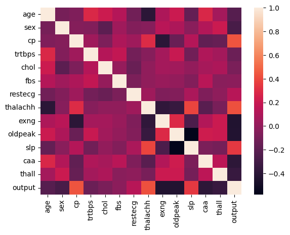

```python
sns.heatmap(df.corr())
plt.show()
```

NOTE :- Therefore, it can be said that no columns will be eliminated because each one of the data's columns has information that will be useful for future prediction.

split the features and target

features

```python
x = df.iloc[:,:-1]
x
```

|  | age | sex | cp | trtbps | chol | fbs | restecg | thalachh | exng | oldpeak | slp | caa | thall |
| --- | --- | --- | --- | --- | --- | --- | --- | --- | --- | --- | --- | --- | --- |
| 0 | 63 | 1 | 3 | 145 | 233 | 1 | 0 | 150 | 0 | 2.3 | 0 | 0 | 1 |
| 1 | 37 | 1 | 2 | 130 | 250 | 0 | 1 | 187 | 0 | 3.5 | 0 | 0 | 2 |
| 2 | 41 | 0 | 1 | 130 | 204 | 0 | 0 | 172 | 0 | 1.4 | 2 | 0 | 2 |
| 3 | 56 | 1 | 1 | 120 | 236 | 0 | 1 | 178 | 0 | 0.8 | 2 | 0 | 2 |
| 4 | 57 | 0 | 0 | 120 | 354 | 0 | 1 | 163 | 1 | 0.6 | 2 | 0 | 2 |
| ... | ... | ... | ... | ... | ... | ... | ... | ... | ... | ... | ... | ... | ... |
| 298 | 57 | 0 | 0 | 140 | 241 | 0 | 1 | 123 | 1 | 0.2 | 1 | 0 | 3 |
| 299 | 45 | 1 | 3 | 110 | 264 | 0 | 1 | 132 | 0 | 1.2 | 1 | 0 | 3 |
| 300 | 68 | 1 | 0 | 144 | 193 | 1 | 1 | 141 | 0 | 3.4 | 1 | 2 | 3 |
| 301 | 57 | 1 | 0 | 130 | 131 | 0 | 1 | 115 | 1 | 1.2 | 1 | 1 | 3 |
| 302 | 57 | 0 | 1 | 130 | 236 | 0 | 0 | 174 | 0 | 0.0 | 1 | 1 | 2 |

303 rows × 13 columns

target

```python
y = df.iloc[:,-1]
y
```

```
0      1
1      1
2      1
3      1
4      1
      ..
298    0
299    0
300    0
301    0
302    0
Name: output, Length: 303, dtype: int64
```

Import a Train Test Split Model

The training set is used to fit the model and adjust its parameters to minimize the error. Once the model is trained, it is evaluated on the testing set to estimate its generalization performance on unseen data.

```python
from sklearn.model_selection import train_test_split
x_train,x_test,y_train,y_test = train_test_split(x,y,test_size=0.3,random_state=42)
```

Import various algorithms

```python
from sklearn.linear_model import LogisticRegression
from sklearn.neighbors import KNeighborsClassifier
from sklearn.tree import DecisionTreeClassifier
from sklearn.svm import SVC
```

Applying variables to algorithms

```python
logreg = LogisticRegression()
knn = KNeighborsClassifier()
dt = DecisionTreeClassifier()
svm = SVC()
```

Import metrics Model for evaluation

```python
from sklearn.metrics import classification_report,accuracy_score
```

Creating a function called Mymodel to make it simple to predict accuracy

Because function allow us to organize and modularize our code, making it more reusable, maintainable, and scalable.

```python
def mymodel(model):
    model.fit(x_train,y_train)
    y_pred = model.predict(x_test)
    print('Accuracy score :',accuracy_score(y_test,y_pred))
    print(classification_report(y_test,y_pred))

    train = model.score(x_train,y_train)
    test = model.score(x_test,y_test)

    print('training performance :',train)
    print('testing performance :',test)

    return model
```

Applying many algorithms to the class to evaluate each one's accuracy and selecting The best and most accurate prediction algorithm

1. Logistic Regression

```python
mymodel(logreg)
```

```
Accuracy score : 0.8131868131868132
              precision    recall  f1-score   support

           0       0.80      0.78      0.79        41
           1       0.82      0.84      0.83        50

    accuracy                           0.81        91
   macro avg       0.81      0.81      0.81        91
weighted avg       0.81      0.81      0.81        91

training performance : 0.8726415094339622
testing performance : 0.8131868131868132
```

```
LogisticRegression()
```

1. KNeighborsClassifier

```python
mymodel(knn)
```

```
Accuracy score : 0.6593406593406593
              precision    recall  f1-score   support

           0       0.63      0.59      0.61        41
           1       0.68      0.72      0.70        50

    accuracy                           0.66        91
   macro avg       0.66      0.65      0.65        91
weighted avg       0.66      0.66      0.66        91

training performance : 0.7688679245283019
testing performance : 0.6593406593406593
```

```
KNeighborsClassifier()
```

1. DecisionTreeClassifier

```python
mymodel(dt)
```

```
Accuracy score : 0.7362637362637363
              precision    recall  f1-score   support

           0       0.68      0.78      0.73        41
           1       0.80      0.70      0.74        50

    accuracy                           0.74        91
   macro avg       0.74      0.74      0.74        91
weighted avg       0.74      0.74      0.74        91

training performance : 1.0
testing performance : 0.7362637362637363
```

```
DecisionTreeClassifier()
```

1. SVM

```python
mymodel(svm)
```

```
Accuracy score : 0.7032967032967034
              precision    recall  f1-score   support

           0       0.79      0.46      0.58        41
           1       0.67      0.90      0.77        50

    accuracy                           0.70        91
   macro avg       0.73      0.68      0.68        91
weighted avg       0.73      0.70      0.69        91

training performance : 0.660377358490566
testing performance : 0.7032967032967034
```

```
SVC()
```

Using the Loop Function to perform hyper parameter tuning

1. Max depth

```python
for i in range(1,101):
    dt1 = DecisionTreeClassifier(max_depth=i)
    dt1.fit(x_train, y_train)
    y_pred = dt1.predict(x_test)
    ac = accuracy_score(y_test, y_pred)
    print(f"max_depth = {i} accuracy = {ac}")
```

```
max_depth = 1 accuracy = 0.6923076923076923
max_depth = 2 accuracy = 0.6923076923076923
max_depth = 3 accuracy = 0.7692307692307693
max_depth = 4 accuracy = 0.7252747252747253
max_depth = 5 accuracy = 0.7582417582417582
max_depth = 6 accuracy = 0.7142857142857143
max_depth = 7 accuracy = 0.7362637362637363
max_depth = 8 accuracy = 0.7142857142857143
max_depth = 9 accuracy = 0.7692307692307693
max_depth = 10 accuracy = 0.7252747252747253
max_depth = 11 accuracy = 0.7142857142857143
max_depth = 12 accuracy = 0.7472527472527473
max_depth = 13 accuracy = 0.7252747252747253
max_depth = 14 accuracy = 0.7142857142857143
max_depth = 15 accuracy = 0.7142857142857143
max_depth = 16 accuracy = 0.7252747252747253
max_depth = 17 accuracy = 0.7472527472527473
max_depth = 18 accuracy = 0.7142857142857143
max_depth = 19 accuracy = 0.7142857142857143
max_depth = 20 accuracy = 0.7582417582417582
max_depth = 21 accuracy = 0.7472527472527473
max_depth = 22 accuracy = 0.7142857142857143
max_depth = 23 accuracy = 0.7252747252747253
max_depth = 24 accuracy = 0.7142857142857143
max_depth = 25 accuracy = 0.7582417582417582
max_depth = 26 accuracy = 0.7252747252747253
max_depth = 27 accuracy = 0.7142857142857143
max_depth = 28 accuracy = 0.7362637362637363
max_depth = 29 accuracy = 0.7252747252747253
max_depth = 30 accuracy = 0.7362637362637363
max_depth = 31 accuracy = 0.7362637362637363
max_depth = 32 accuracy = 0.7472527472527473
max_depth = 33 accuracy = 0.7472527472527473
max_depth = 34 accuracy = 0.7142857142857143
max_depth = 35 accuracy = 0.7142857142857143
max_depth = 36 accuracy = 0.7362637362637363
max_depth = 37 accuracy = 0.7032967032967034
max_depth = 38 accuracy = 0.7252747252747253
max_depth = 39 accuracy = 0.7472527472527473
max_depth = 40 accuracy = 0.7142857142857143
```

[output cut: 45 more lines]

```
max_depth = 86 accuracy = 0.7142857142857143
max_depth = 87 accuracy = 0.7362637362637363
max_depth = 88 accuracy = 0.7142857142857143
max_depth = 89 accuracy = 0.7032967032967034
max_depth = 90 accuracy = 0.7582417582417582
max_depth = 91 accuracy = 0.7362637362637363
max_depth = 92 accuracy = 0.7362637362637363
max_depth = 93 accuracy = 0.7032967032967034
max_depth = 94 accuracy = 0.7142857142857143
max_depth = 95 accuracy = 0.7472527472527473
max_depth = 96 accuracy = 0.7252747252747253
max_depth = 97 accuracy = 0.7142857142857143
max_depth = 98 accuracy = 0.7142857142857143
max_depth = 99 accuracy = 0.7472527472527473
max_depth = 100 accuracy = 0.7032967032967034
```

2.Minimum sample split

```python
for i in range(2,101):
    dt1 = DecisionTreeClassifier(criterion='entropy',min_samples_split=i)
    dt1.fit(x_train,y_train)
    y_pred = dt1.predict(x_test)
    ac = accuracy_score(y_test,y_pred)
    print(f"min sample spilt = {i} accuracy={ac}")
```

```
min sample spilt = 2 accuracy=0.7252747252747253
min sample spilt = 3 accuracy=0.7142857142857143
min sample spilt = 4 accuracy=0.7252747252747253
min sample spilt = 5 accuracy=0.7252747252747253
min sample spilt = 6 accuracy=0.7362637362637363
min sample spilt = 7 accuracy=0.7472527472527473
min sample spilt = 8 accuracy=0.7362637362637363
min sample spilt = 9 accuracy=0.7142857142857143
min sample spilt = 10 accuracy=0.7142857142857143
min sample spilt = 11 accuracy=0.7142857142857143
min sample spilt = 12 accuracy=0.7142857142857143
min sample spilt = 13 accuracy=0.7142857142857143
min sample spilt = 14 accuracy=0.7142857142857143
min sample spilt = 15 accuracy=0.7142857142857143
min sample spilt = 16 accuracy=0.7142857142857143
min sample spilt = 17 accuracy=0.7142857142857143
min sample spilt = 18 accuracy=0.7142857142857143
min sample spilt = 19 accuracy=0.7142857142857143
min sample spilt = 20 accuracy=0.7692307692307693
min sample spilt = 21 accuracy=0.7692307692307693
min sample spilt = 22 accuracy=0.7692307692307693
min sample spilt = 23 accuracy=0.7692307692307693
min sample spilt = 24 accuracy=0.7692307692307693
min sample spilt = 25 accuracy=0.7692307692307693
min sample spilt = 26 accuracy=0.7692307692307693
min sample spilt = 27 accuracy=0.7692307692307693
min sample spilt = 28 accuracy=0.7692307692307693
min sample spilt = 29 accuracy=0.7692307692307693
min sample spilt = 30 accuracy=0.7692307692307693
min sample spilt = 31 accuracy=0.7692307692307693
min sample spilt = 32 accuracy=0.7692307692307693
min sample spilt = 33 accuracy=0.7692307692307693
min sample spilt = 34 accuracy=0.7692307692307693
min sample spilt = 35 accuracy=0.6703296703296703
min sample spilt = 36 accuracy=0.6703296703296703
min sample spilt = 37 accuracy=0.6703296703296703
min sample spilt = 38 accuracy=0.6703296703296703
min sample spilt = 39 accuracy=0.6703296703296703
min sample spilt = 40 accuracy=0.6593406593406593
min sample spilt = 41 accuracy=0.6593406593406593
```

[output cut: 44 more lines]

```
min sample spilt = 86 accuracy=0.6593406593406593
min sample spilt = 87 accuracy=0.6593406593406593
min sample spilt = 88 accuracy=0.6593406593406593
min sample spilt = 89 accuracy=0.6593406593406593
min sample spilt = 90 accuracy=0.6593406593406593
min sample spilt = 91 accuracy=0.6923076923076923
min sample spilt = 92 accuracy=0.6923076923076923
min sample spilt = 93 accuracy=0.6923076923076923
min sample spilt = 94 accuracy=0.6923076923076923
min sample spilt = 95 accuracy=0.6923076923076923
min sample spilt = 96 accuracy=0.6923076923076923
min sample spilt = 97 accuracy=0.6923076923076923
min sample spilt = 98 accuracy=0.6923076923076923
min sample spilt = 99 accuracy=0.6923076923076923
min sample spilt = 100 accuracy=0.6923076923076923
```

3.Minimun sample leaf

```python
for i in range(2,101):
    dt1 = DecisionTreeClassifier(criterion='entropy',min_samples_leaf=i)
    dt1.fit(x_train,y_train)
    y_pred = dt1.predict(x_test)
    ac = accuracy_score(y_test,y_pred)
    print(f"min sample spilt = {i} accuracy={ac}")
```

```
min sample spilt = 2 accuracy=0.6373626373626373
min sample spilt = 3 accuracy=0.7362637362637363
min sample spilt = 4 accuracy=0.7582417582417582
min sample spilt = 5 accuracy=0.7142857142857143
min sample spilt = 6 accuracy=0.7142857142857143
min sample spilt = 7 accuracy=0.7142857142857143
min sample spilt = 8 accuracy=0.7142857142857143
min sample spilt = 9 accuracy=0.7692307692307693
min sample spilt = 10 accuracy=0.8021978021978022
min sample spilt = 11 accuracy=0.8021978021978022
min sample spilt = 12 accuracy=0.8021978021978022
min sample spilt = 13 accuracy=0.8021978021978022
min sample spilt = 14 accuracy=0.8021978021978022
min sample spilt = 15 accuracy=0.8021978021978022
min sample spilt = 16 accuracy=0.7802197802197802
min sample spilt = 17 accuracy=0.7802197802197802
min sample spilt = 18 accuracy=0.7032967032967034
min sample spilt = 19 accuracy=0.7032967032967034
min sample spilt = 20 accuracy=0.6923076923076923
min sample spilt = 21 accuracy=0.6923076923076923
min sample spilt = 22 accuracy=0.6923076923076923
min sample spilt = 23 accuracy=0.6923076923076923
min sample spilt = 24 accuracy=0.6923076923076923
min sample spilt = 25 accuracy=0.6923076923076923
min sample spilt = 26 accuracy=0.6923076923076923
min sample spilt = 27 accuracy=0.6923076923076923
min sample spilt = 28 accuracy=0.6923076923076923
min sample spilt = 29 accuracy=0.6923076923076923
min sample spilt = 30 accuracy=0.6923076923076923
min sample spilt = 31 accuracy=0.6923076923076923
min sample spilt = 32 accuracy=0.6923076923076923
min sample spilt = 33 accuracy=0.6923076923076923
min sample spilt = 34 accuracy=0.6923076923076923
min sample spilt = 35 accuracy=0.6923076923076923
min sample spilt = 36 accuracy=0.6923076923076923
min sample spilt = 37 accuracy=0.6923076923076923
min sample spilt = 38 accuracy=0.6923076923076923
min sample spilt = 39 accuracy=0.6923076923076923
min sample spilt = 40 accuracy=0.6923076923076923
min sample spilt = 41 accuracy=0.6923076923076923
```

[output cut: 44 more lines]

```
min sample spilt = 86 accuracy=0.7802197802197802
min sample spilt = 87 accuracy=0.7802197802197802
min sample spilt = 88 accuracy=0.7802197802197802
min sample spilt = 89 accuracy=0.7802197802197802
min sample spilt = 90 accuracy=0.7802197802197802
min sample spilt = 91 accuracy=0.7802197802197802
min sample spilt = 92 accuracy=0.7802197802197802
min sample spilt = 93 accuracy=0.7802197802197802
min sample spilt = 94 accuracy=0.7802197802197802
min sample spilt = 95 accuracy=0.7802197802197802
min sample spilt = 96 accuracy=0.7802197802197802
min sample spilt = 97 accuracy=0.6923076923076923
min sample spilt = 98 accuracy=0.6923076923076923
min sample spilt = 99 accuracy=0.6923076923076923
min sample spilt = 100 accuracy=0.6923076923076923
```

```python
df_new = DecisionTreeClassifier(criterion='entropy',max_depth=44,min_samples_split=20,min_samples_leaf=10)
```

```python
mymodel(df_new)
```

```
Accuracy score : 0.8021978021978022
              precision    recall  f1-score   support

           0       0.77      0.80      0.79        41
           1       0.83      0.80      0.82        50

    accuracy                           0.80        91
   macro avg       0.80      0.80      0.80        91
weighted avg       0.80      0.80      0.80        91

training performance : 0.8726415094339622
testing performance : 0.8021978021978022
```

```
DecisionTreeClassifier(criterion='entropy', max_depth=44, min_samples_leaf=10,
                       min_samples_split=20)
```

Best model

```python
mymodel(logreg)
```

```
Accuracy score : 0.8131868131868132
              precision    recall  f1-score   support

           0       0.80      0.78      0.79        41
           1       0.82      0.84      0.83        50

    accuracy                           0.81        91
   macro avg       0.81      0.81      0.81        91
weighted avg       0.81      0.81      0.81        91

training performance : 0.8726415094339622
testing performance : 0.8131868131868132
```

```
LogisticRegression()
```

# CONCLUSION

Heart Disease is a fatal disease by its nature. This disease makes a life threatening complexities such as heart attack and death. The importance of Data Mining in the Medical Domain is realized and steps are taken to apply relevant techniques in the Disease Prediction.